# Report: Connecting Transit Deserts in Greater Philadelphia: Recommendations for SEPTA’s MicroTransit

Riya Saini

## **Transit Deserts and the Case for Microtransit**

Transit deserts are defined as areas with limited or no access to reliable public transportation, where residents must travel long distances to reach transit services or depend on private vehicles. These deserts often arise from a mismatch between transit demand and supply, even in regions with extensive infrastructure (Choi & Jiao, 2024) due to limited service frequency, high travel times, or inequitable transit coverage (“Transit Deserts,” 2020). It disproportionately impacts seniors, low-income individuals, caregivers, and people with disabilities. Inadequate service in these areas restricts access to jobs, healthcare, education, and other essential opportunities, thereby exacerbating social and economic inequities.

In response, public agencies have been increasingly opting for a flexible, on-demand microtransit service (Walker, n.d., APTAAdmin, n.d.). Programs like Via New Jersey, launched in 2020, have delivered over 2 million rides, with 80% of users as people of color, and 13% with a disability (From Transit Deserts to Two Million Rides, 2024) while services in suburban Bay Area communities, such as SamTrans Ride Plus, Silicon Valley Hopper, and MoGo Morgan Hill Quick Ride, help residents access key destinations within a 30-minute travel window.

## **Objectives**

Although much of the City of Philadelphia is within a 30-minute reach of a transit line, the outer-ring suburbs in West Chester, Malvern, Paoli, Great Valley, Norristown, Lansdale, Telford, Levittown, and Bristol are transit deserts. These communities include a mix of land uses—from office parks and pharmaceutical campuses to senior housing and low-income residential developments. Many of these areas currently receive infrequent bus service, often aligned with corporate schedules and limited to hourly frequencies six days a week. This renders the service inaccessible for residents who lack private vehicles or work non-traditional hours.

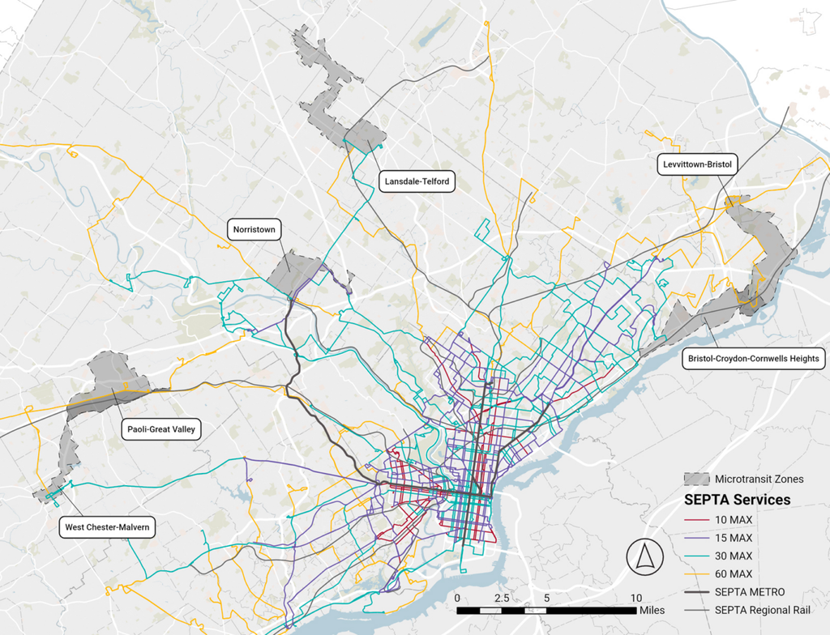

*Image from SEPTA Microtransit website showing SEPTA GO zones and service frequency*

As part of its New Bus Network redesign, SEPTA is preparing to launch a microtransit service aimed at improving transit accessibility in these low-density areas that have historically been difficult to serve with high-frequency fixed-route buses. The microtransit model, planned as a community circulator, will enable riders to request trips within designated GO service zones and connect directly to SEPTA’s broader transit network—including bus, rail, and Metro services (Microtransit – Southeastern Pennsylvania Transportation Authority, n.d.). As Harley Cooper, Director of Suburban Service Planning – Bus & Metro at SEPTA, emphasized, the program is not intended as an expansion of transit service but rather as a strategic reallocation of resources, replacing low-ridership and infrequent bus routes with a more flexible, demand-responsive system (H. Cooper, personal communication, March 2025).

## **SEPTA Timeline**

As of 2023, SEPTA completed vehicle procurement and the implementation of microtransit software (Microtransit – Southeastern Pennsylvania Transportation Authority, n.d.). The phased rollout of SEPTA’s Microtransit service under “SEPTA GO” is scheduled to begin in summer 2025, with system-wide schedule updates, the elimination of certain route patterns, and the introduction of service in Paoli and West Chester, along with the launch of the new Route 142 following the July 1 “B” pick. In fall 2025, SEPTA GO service will expand to include the Norristown zone. By late July 2026, major implementation is planned in Northeast Philadelphia, specifically in the Comly and Frankford areas, with additional expansion into Lower Bucks County and the launch of new SEPTA GO zones in Lansdale, Bristol, and Levittown.

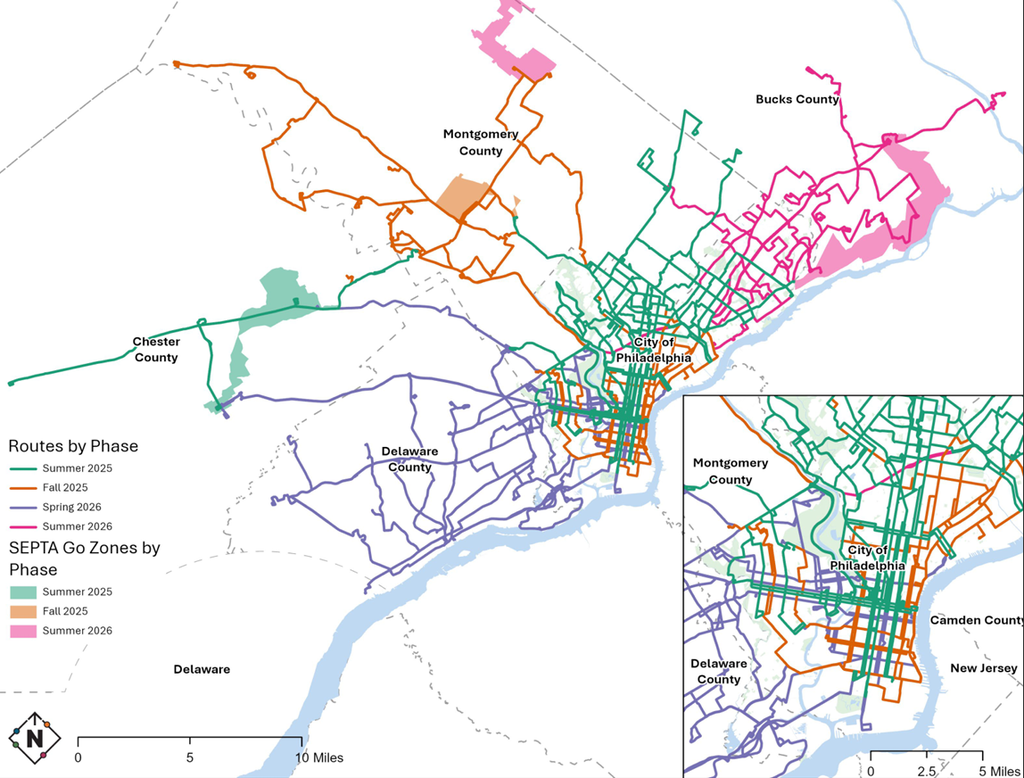

*SEPTA GO, PennDOT Update, Nov 2024, shared by Harley Cooper*

### Organization Structure

In 1964, the Southeastern Pennsylvania Transportation Authority was created with a goal of establishing a permanent, unified public transportation system for the greater Philadelphia region. Over the decades, SEPTA has evolved into the fifth-largest transit agency in the country, operating an integrated network of buses, subways, trolleys, and regional rail, as well as ADA paratransit and Shared Ride services (SEPTA, n.d.).

The agency is governed by a 15-member board, with appointments made by city, county, and state officials while the General Manager oversees day-to-day operations through eight major departments. SEPTA’s governance structure reflects a legacy of regional compromise. Each county receives equal board representation, despite Philadelphia accounting for the majority of transit service demand. This imbalance has historically fueled political tensions within the board as suburban representatives and Philadelphia advocate differing priorities. However, SEPTA’s Microtransit initiative emerged as a point of rare consensus with support from suburban board members as the service targets low-density areas. This broad support has allowed the agency to advance procurement and implementation more smoothly than in other transit reform efforts (H. Cooper, personal communication, March 2025).

### Funding Challenges

Public transit funding in Pennsylvania is shaped by decisions made at the state and federal levels whose transportation policies have largely favored highway investments in rural areas while underfunding urban transit systems like SEPTA. Philadelphia’s strained political relationship with Harrisburg continues to complicate efforts to secure stable transit funding. With the state legislature under Republican control, long-standing opposition to public transit subsidies and skepticism toward federal infrastructure spending persist (Perrin, 2024). This dynamic places SEPTA’s financial stability at risk, especially as the agency seeks recurring funding to support both core operations and system innovations like microtransit.

At present, SEPTA is facing an ongoing financial crisis, described as a “death spiral” stemming from long-term structural funding deficits. Without continued support, SEPTA projects a 20% reduction in service and a 21.5% fare increase, following the already enacted 7.5% fare hike, the first in a decade (Mayk, 2025). Although capital projects under SEPTA Forward are progressing, the Microtransit program remains on hold due to the absence of confirmed state funding (Tomczuk, 2023).

### Operating Cost

To estimate costs for the Microtransit program, SEPTA used a baseline of $100 per revenue hour using a simplified hourly rate approach for initial microtransit cost projections (H. Cooper, personal communication, March 2025). SEPTA’s proposed on-demand microtransit service will operate 90,000 revenue hours across 21 vehicles, at a cost of approximately $10.54 million. When added to the fixed-route redesign, the total system would operate at 3.82 million revenue hours. However, the plan would reduce total operating and maintenance costs by $22.07 million—a 3.5% decrease—and reduce the peak fleet by 126 buses, even with the addition of microtransit (SEPTA, 2023).

Each on-demand vehicle, modeled after SEPTA’s existing paratransit shuttle, is estimated to cost $300,000. While less expensive than a standard 40-foot bus ($800,000–$900,000), the microtransit vehicles require additional upgrades to meet ADA standards, including low floors, bike racks, digital headsigns, and a 14 passenger capacity, which increase capital costs. While the New Bus Network is designed to be revenue-neutral, however, without dedicated operating and capital funding, its full deployment has been delayed, with resources currently prioritized for essential maintenance.

### Operating Model

SEPTA’s microtransit program will operate from existing depots, retrofitted with upgraded fueling infrastructure to accommodate non-gasoline vehicles. The service will utilize unionized operators and mechanics, preserving labor standards across both fixed-route and on-demand operations. Operators will have the option to choose between microtransit and traditional bus assignments. SEPTA also partnered with RideCo, through a competitive RFP process to deliver the backend scheduling platform and user-facing interface (H. Cooper, personal communication, March 2025). Integrated with SEPTA Access, the agency’s ADA paratransit program, both services will share the same control center, reservation line, and dispatching infrastructure, ensuring consistency and resource efficiency. The agency has procured 25 ADA-compliant vehicles, configured with a contingency plan to allow for redeployment to paratransit service if necessary (H. Cooper, personal communication, March 2025).

## **Pilot Program**

While full-scale deployment of SEPTA’s microtransit service has been delayed due to funding constraints, the agency launched a pilot program in partnership with Via in Lower Bucks County, a region with a significant concentration of Section 8 housing and elderly population (H. Cooper, personal communication, March 2025). The pilot utilized a single vehicle to provide on-demand, zone-based service to residents with limited access to fixed-route transit, offering connectivity to essential destinations such as grocery stores and clinics. Early feedback has been overly positive, with estimated time savings of 15–30 minutes per trip- an improvement from previous wait times of 60 to 90 minutes. Public engagement during the Bus Revolution process also demonstrated a broad support for the microtransit concept, especially when the service was presented with fare parity to existing bus routes. According to the 2023 Summary of Stakeholder and Community Engagement, approximately two-thirds of respondents from suburban counties expressed support for an on-demand SEPTA shuttle service. However, the same report also noted a lack of detailed community input, particularly in suburban areas outside of Philadelphia, highlighting the need for expanded outreach to build awareness and inform service design (Southeastern Pennsylvania Transportation Authority [SEPTA], 2023).

## **Case Studies**

### Bay Transit Express (Gloucester County, Virginia)

Bay Transit Express, operated by a nonprofit in eastern Virginia, offers a compelling example of a cost-effective and community-focused microtransit deployment (Virginia Department of Rail and Public Transportation [DRPT], 2023). Launched in June 2021 as a weekday on-demand pilot, the service initially operated with a modest fleet of three vehicles—a Ford E450, a Ford Transit 350, and a six-seat Ford Transit van. It targeted low-income residents, older adults, individuals with disabilities, and those without access to a private vehicle. With fares set at $1 per ride, it was designed to be affordable and accessible. The pilot achieved average wait times (ETAs) of just 11 minutes, with only 8% of trips exceeding 25 minutes. After the service zone was expanded to include Gloucester Point, ridership more than doubled, rising from an average of 502 trips to 1,293 trips in December 2022. The program also reported an 85% repeat rider rate, suggesting strong satisfaction and trust among the target population.

Its success was measured through multiple performance indicators such as ride-sharing rates, utilization per vehicle hour, peak service periods, and cost per vehicle hour (approximately $40). The highest productivity was recorded between 10 AM and 12 PM, and sharing rates climbed to 28% by the end of 2022. The pilot’s success was attributed to a combination of factors:

- Targeted outreach to transit-dependent populations
- Optimized zone design and wait times
- Simple and low fare structure
- Robust community engagement and hyperlocal marketing

### LA Metro MicroTransit Pilot (Los Angeles County, California)

In contrast to Bay Transit’s modest model, LA Metro’s MicroTransit Pilot Program (MTP) was launched at a much larger scale in 2017 with federal seed funding from the FTA’s Mobility on Demand Sandbox initiative (Los Angeles County Metropolitan Transportation Authority [LA Metro], 2023). The program was designed to supplement Metro’s fixed-route network and provide first/last-mile connections in urban areas across North Hollywood/Burbank, El Monte, and Compton/Artesia. The service operated 7 days a week, with revenue service hours between 9 AM and 10 PM, depending on the zone. LA Metro partnered with RideCo to provide dispatching software and leased up to 16 accessible vans. However, the pilot faced multiple challenges and became the subject of public scrutiny.

In March 2024, fares were raised from $1.00 to $2.50, a 150% increase, triggering widespread public backlash. The agency subsequently integrated discount programs such as LIFE, GoPass, and Senior TAP cards, but the damage to public perception lingered. Ridership remained at just 2,300 daily riders- less than half of Metro’s stated goal of 5,090—despite operating across a large urban geography (Los Angeles County Metropolitan Transportation Authority [LA Metro], 2024). At its peak, the program’s cost per trip was $62.97, later reduced to $29.06 after route adjustments and operational improvements—but still far higher than conventional transit services. Metro attempted to address cost inefficiencies by implementing flexible operator scheduling, consolidating underperforming zones as well as reallocating operators across service areas

Despite modest gains in passengers per vehicle hour (PVH) to 3.55 in February 2024, the service struggles to demonstrate long-term viability. As the Amalgamated Transit Union (ATU)’s The False Promise of Microtransit report cautions, microtransit may serve niche use cases, but without accountability, it can become a costly parallel system rather than a genuine complement to fixed-route transit (Amalgamated Transit Union [ATU], n.d.).

## **Recommendations**

In alignment with SEPTA’s draft GO Performance Monitoring metrics, SEPTA’s pilot experience, and comparative case studies from Bay Transit and LA Metro, the following recommendations are proposed to guide the successful implementation of SEPTA’s Microtransit program:

1. Both Bay Transit and LA Metro showcase the importance of targeting transit-dependent populations, particularly low-income residents, older adults, and individuals with disabilities. SEPTA should maintain its current equity-centered approach.

2. Bay Transit’s success was driven by short wait times and service reliability whereas LA Metro struggled due to service inconsistencies and high per-trip costs. SEPTA must deliver predictable ETAs, low wait times, and reliable scheduling to establish rider trust.

3. As demonstrated by LA Metro, strategic scheduling and dynamic service allocation can significantly lower per-trip costs over time. Metrics such as passengers per revenue hour, cost per trip, and vehicle utilization should be used to inform targeted adjustments to service hours, zone boundaries, or vehicle allocation.

4. Customer satisfaction and repeat ridership are key to long-term viability. SEPTA should maintain a similar metric to assuage low-repeat use zones.

5. LA Metro’s early fare increase hindered access while Bay Transit’s consistent $1 fare promoted widespread usage. SEPTA should continue to maintain fare parity with bus service and any fare adjustments should be phased and publicly vetted, with safeguards to protect vulnerable users.

6. Bay Transit’s high repeat ridership (85%) was supported by strong community ties and grassroots promotion. SEPTA should follow a similar outreach strategy and partner with local organizations such as libraries, senior centers, and clinics. To ensure transparency, SEPTA ought to publish its performance results on a public dashboard regularly.

## **References**

1. ADA Paratransit Service – Southeastern Pennsylvania Transportation Authority. (n.d.). Retrieved February 28, 2025, from https://wwww.septa.org/cct/ada-paratransit-service/
2. APTAAdmin. (n.d.). Microtransit. American Public Transportation Association. Retrieved February 27, 2025, from https://www.apta.com/research-technical-resources/mobility-innovation-hub/microtransit/
3. Choi, S. J., & Jiao, J. (2024). Developing a transit desert interactive dashboard: Supervised modeling for forecasting transit deserts. PLOS ONE, 19(7), e0306782. https://doi.org/10.1371/journal.pone.0306782
4. From transit deserts to two million rides: Four years of microtransit in Jersey City. (2024, February 28). https://ridewithvia.com/resources/from-transit-deserts-to-two-million-rides-four-years-of microtransit-in-jersey-city
5. Mayk, L. (2025, February 21). SEPTA’s general manager warns service cuts, fare increases likely if funding doesn’t pass. NBC10 Philadelphia. https://www.nbcphiladelphia.com/news/local/septa-death-spiral-funding-service-cuts-fare-increases/4115853/
6. Microtransit – Southeastern Pennsylvania Transportation Authority. (n.d.). Retrieved February 28, 2025, from https://wwww.septa.org/initiatives/better-bus/microtransit/
7. Microtransit: The Solution to Public Transit Deserts? (n.d.). Retrieved February 28, 2025, from https://www.triplepundit.com/story/2023/via-microtransit-public-transportation/773701
8. Perrin, D. (2024, December 5). Swarthmore and the Urban Politics of SEPTA - The Phoenix. https://swarthmorephoenix.com/2024/12/05/swarthmore-and-the-urban-politics-of-septa/
9. SEPTA. (n.d.). Encyclopedia of Greater Philadelphia. Retrieved February 28, 2025, from https://philadelphiaencyclopedia.org/essays/septa/
10. Shared-Ride Program – Southeastern Pennsylvania Transportation Authority. (n.d.). Retrieved February 28, 2025, from https://wwww.septa.org/cct/shared-ride-program/
11. Transit Deserts: Equity analysis of public transit accessibility. (2020). Journal of Transport Geography, 89, 102869. https://doi.org/10.1016/j.jtrangeo.2020.102869
12. Walker, A. (n.d.). Regulating Microtransit in San Francisco: Greener Transportation or the End of Public Transit For All? Environmental Law Journal, Volume 26. Retrieved February 28, 2025, from https://nyuelj.org/issues-2/volume-26/
13. CCT Connect – Southeastern Pennsylvania Transportation Authority. (n.d.). Retrieved April 24, 2025, from https://wwww.septa.org/cct/
14. Tomczuk, J. (2023, December 11). SEPTA’s Bus Revolution network redesign poised for final approval – Metro Philadelphia. https://metrophiladelphia.com/septa-bus-revolution-redesign/
15. Los Angeles County Metropolitan Transportation Authority. (2023, June 20). Microtransit pilot project update report. https://www.metro.net
16. Los Angeles County Metropolitan Transportation Authority. (2024, June 20). Microtransit pilot project update report to the Operations, Safety, and Customer Experience Committee. https://www.metro.net
17. Virginia Department of Rail and Public Transportation. (2023, April). Rural microtransit case study and report. https://drpt.virginia.gov
18. Amalgamated Transit Union. (n.d.). The false promise of microtransit. https://www.atu.org
19. Southeastern Pennsylvania Transportation Authority. (2023, August). Summary of stakeholder and community engagement: Bus Revolution. https://www.septa.org